# Data Analysis

Yihan Wang

2024-01/02

# 1 Import Packages

```r
library(readr)
library(tidyverse)
library(dplyr)
library(stringr)
library(jsonlite)
library(knitr)
library(kableExtra)
library(papaja)
library(rstatix)
library(psych)
knitr::opts_chunk$set(echo = TRUE)
#library(irr)
#library(magrittr)
#library(ggpubr)
```

# 2 Data Read In

```r
# experiment dataset downloaded via Railway code, including open-ended questions' answers
fulldata <- read.csv("data/fulldata.csv")
```

# 3 Data Cleaning Step 1 - Access

## 3.1 Responses Scores from Each Participants

```r
# response scores for each stimulus
response_data <- fulldata %>%
  select(PROLIFIC_PID, stimulus, response) %>%
  na.omit()

response_data$stimulus_num <- as.numeric(sub(".*/(\\d+)\\.jpeg", "\\1", response_data$stimulus))

# arrange the format
responses <- response_data %>%
  arrange(stimulus_num) %>%
  pivot_wider(
    id_cols = PROLIFIC_PID,
    names_from = stimulus_num,
    values_from = response)
```

Some rows need to be dropped. Drop manully: the 1st row recorded the answer by myself to test, and other rows of unreliable answers. Some participants rate all pictures with the same number for quicker completion or feel unethical to judge people based on their looks.

```r
# drop certain rows
responses <- responses[-c(1, 12, 15, 94, 98, 106), ]
```

## 3.2 Answers of the Open-ended Questions from Each Participants

```r
# access answers of open-ended questions
openq_data <- fulldata %>%
  select(PROLIFIC_PID, form_data) %>%
  na.omit() %>%
  filter(str_detect(form_data, "whatTested"))

# format all answers into columns
openq_answer <- list()
for (i in seq_along(openq_data$form_data)) {
  openq_answer[[i]] <- fromJSON(openq_data$form_data[i],
                                simplifyDataFrame = FALSE)
}
openq_answer_df <- bind_rows(openq_answer)
```

The openq_answer_df has 161 rows, which is inconsistent with the participants numbers. This is because the fromJSON function identified multiple race information into separate rows, and result in multiple rows for one participants. To solve that, I output the df into a csv file and reorganize manually. I also add the Prolific id back to the df.

```r
write.csv(openq_answer_df, "data/openq_answer_df.csv")
# The new edited file is called "openq_full.csv"
openq_full <- read.csv("data/openq_full.csv") # before drop unreliable
```

My dataset for now has been tidied for further analysis. In the “responses_full.csv”, each column represents one stimulus, each row stands for each participants, and each cell is a single measurement of the rated competence score. For further analysis, I will need to do the test-retest reliability check and assign conditions to facial stimuli, which will require me to build dataset in different format based on “responses_full.csv”. In “openq_full.csv”, the participants’ sex and race are my main focus because this might influence their judgments on my facial stimuli, which categorized by gender and race.

# 4 Data Cleaning Step 2 - Check

## 4.1 With-in Raters Reliability (Test-retest) Check

Each participant’s within-rater reliability was defined as the Pearson correlation between ratings on the first and second presentation of the last 24 repeated images. A positive correlation indicates an overall consistent response to the stimuli from that rater. Unreliable raters were defined as those with within-rater reliability less than or equal to 0.

Pics arranged in 9 blocks to counter balance. Block1:-2,+2,0. Block2:0,-2,+2. Block3:+2,0,-2

Stimuli numbers >126 = repeat pics(format = stimulus_stinum-repeated_stinum) 127-8. 128-63. 129-33. 130-56. 131-44. 132-25. 133-93. 134-87. 135-96. 136-77. 137-72. 138-89. 139-34. 140-46. 141-80. 142-50. 143-11. 144-15. 145-66. 146-35. 147-60. 148-5. 149-24. 150-57.

To Calculate the Pearson correlation for each participants, there will be a dataframe for each participants. 24 rows (24 repeated pics) * 2 columns (first presentation, second presentation), and rating scores from the participants in each cell.

```r
# assign stimuli numbers
first_presentation_stinum <- c(8, 63, 33, 56, 44, 25, 93, 87, 96, 77, 72, 89, 34, 46, 80, 50, 11, 15, 66, 35, 60, 5, 24, 57)
second_presentation_stinum <- c(127:150)
# increment each item by 1, because of the PROLIFIC_PID column
first_presentation_stinum <- first_presentation_stinum + 1
second_presentation_stinum <- second_presentation_stinum + 1

# set the function to calculate the Pearson correlation
calculate_correlation <- function(responses) {
  # create two small dataframes then combine them to calculate the Pearson correlation
  # Args:
  #   responses : the full dataset that stores all responses from the participants
  # Returns:
  #   the specific Pearson correlation score for each participants
  first_all <- responses %>%
    select(first_presentation_stinum) %>%
    pivot_longer(cols = everything(),
                  names_to = "first_stinum",
                  values_to = "first_rating")
  second_all <- responses %>%
    select(second_presentation_stinum) %>%
    pivot_longer(cols = everything(),
                  names_to = "second_stinum",
                  values_to = "second_rating")
  test_all <- cbind(first_all,second_all)
  correlation <- cor(test_all$first_rating, test_all$second_rating)
  return(correlation)
}

# call the function in each row using for loop
correlation_result <- list()
for (i in 1:nrow(responses)) {
  correlation_result[[i]] <- calculate_correlation(responses[i, ])
}


# determine unreliable
unreliable <- which(sapply(correlation_result, function(x) x <= 0))


# Remove unreliable participants &
# Drop the Scores for the last 24 pictures, because they are only for reliability check purposes.
responses <- responses[-c(unreliable), ] %>%
            select(-(128:151))

#write.csv(responses, "data/responses.csv")
```

# 5 Data Cleaning Step 3 - Organize

Then, assign stimulus conditions.

```r
# gender
#male <- list(1,2,4,6,10,12,14,15,16,20,22,23,27,28,29,30,32,36,37,39,41,44,45,50,51,52,54,56,58,59,60,63,65,67,68,72,73,74,77,80,81,84,85,86,87,90,93,96,97,101,103,105,106,107,110,112,115,118,120,121,123,124,126)
#female <- list(3,5,7,8,9,11,13,17,18,19,21,24,25,26,31,33,34,35,38,40,42,43,46,47,48,49,53,55,57,61,62,64,66,69,70,71,75,76,78,79,82,83,88,89,91,92,94,95,98,99,100,102,104,108,109,111,113,114,116,117,119,122,125,127,129,132,138,139,140,143,145,146,148,149,150)
male_stimuli <- c(1,2,4,6,10,12,14,15,16,20,22,23,27,28,29,30,32,36,37,39,41,44,45,50,51,52,54,56,58,59,60,63,65,67,68,72,73,74,77,80,81,84,85,86,87,90,93,96,97,101,103,105,106,107,110,112,115,118,120,121,123,124,126)
female_stimuli <- c(3,5,7,8,9,11,13,17,18,19,21,24,25,26,31,33,34,35,38,40,42,43,46,47,48,49,53,55,57,61,62,64,66,69,70,71,75,76,78,79,82,83,88,89,91,92,94,95,98,99,100,102,104,108,109,111,113,114,116,117,119,122,125)

# weight
minus2 <- c(1,2,3,4,5,6,7,8,9,10,11,12,13,14,57,58,59,60,61,62,63,64,65,66,67,68,69,70,113,114,115,116,117,118,119,120,121,122,123,124,125,126)
zero <- c(29,30,31,32,33,34,35,36,37,38,39,40,41,42,43,44,45,46,47,48,49,50,51,52,53,54,55,56,99,100,101,102,103,104,105,106,107,108,109,110,111,112)
plus2 <- c(15,16,17,18,19,20,21,22,23,24,25,26,27,28,71,72,73,74,75,76,77,78,79,80,81,82,83,84,85,86,87,88,89,90,91,92,93,94,95,96,97,98)

# race
asian <- c(7,8,12,13,16,19,21,23,27,28,30,32,38,42,43,48,51,54,56,57,60,63,66,68,71,75,78,84,87,89,97,98,99,104,106,111,112,113,115,119,121,124)
white <- c(1,4,5,10,11,15,18,20,22,25,31,34,37,40,45,50,52,53,58,61,69,73,76,77,79,80,90,91,92,95,100,103,105,107,108,109,117,118,122,123,125,126)
black <- c(2,3,6,9,14,17,24,26,29,33,35,36,39,41,44,46,47,49,55,59,62,64,65,67,70,72,74,81,82,83,85,86,88,93,94,96,101,102,110,114,116,120)

# responses mean & assign conditions
mean_con <- responses %>% summarize(across(everything(), mean, na.rm = TRUE))%>%
  subset(select = -1) %>%
  pivot_longer(cols = everything(),                                                              names_to = "stimulus_num",
               values_to = "mean_score") %>% # get mean score of each stimulus
  mutate(sti_gender = if_else(stimulus_num %in% female_stimuli, "female", "male")) %>%
  mutate(sti_weight = case_when(
    stimulus_num %in% minus2 ~ -2,
    stimulus_num %in% zero ~ 0,
    stimulus_num %in% plus2 ~ +2)) %>%
  mutate(sti_race = case_when(
    stimulus_num %in% asian ~ "Asian",
    stimulus_num %in% white ~ "White",
    stimulus_num %in% black ~ "Black"))
#write.csv(mean_con, "data/responses_meancon.csv")
```

# 6 Fitting Model - ANOVA

Since the stimuli are repeated in three levels of weight conditions (minus2, zero, plus2) and grouped in gender and race. Since the weight conditions can be viewed as a repeated condition, I will use repeated measurements ANOVA for this within subject design. ANOVA is more sensitive to the difference within each condition than between group variance. The dependent variable will be the evaluations of competence, which will be quantified based on the ratings given by the participants. The independent variables will be weight (-2, 0, +2 SD), gender (male, female), and race (White, Black, Asian). We predict an interaction (significance) between gender and weight conditions. There might be racial differences in how weight influences perceived competence. See Table6.1 for a summary of the analysis.

```r
anova_data <- responses %>%
  pivot_longer(
    cols = 2:127,
    names_to = "sti_num",
    values_to = "responses"
  ) %>%
  mutate(sti_gender = if_else(sti_num %in% female_stimuli, "female", "male"),
         sti_weight = case_when(
           sti_num %in% minus2 ~ "minus2",
           sti_num %in% zero ~ "zero",
           sti_num %in% plus2 ~ "plus2"),
         sti_race = case_when(
           sti_num %in% asian ~ "Asian",
           sti_num %in% white ~ "White",
           sti_num %in% black ~ "Black"))
#write.csv(anova_data, "data/anova_data.csv")
```

```r
anova_data_group <- anova_data %>%
  group_by(PROLIFIC_PID, sti_gender, sti_weight) %>%
  summarise(mean_response = mean(responses, na.rm = TRUE))
anova_data_group <- data.frame(anova_data_group)
#write.csv(anova_data_group, "data/anova_data_group.csv")
```

```r
gender_anova <- anova_test(data=anova_data_group,
                      dv = "mean_response",
                      wid= "PROLIFIC_PID",
                      within=c("sti_gender", "sti_weight"),
                      effect.size="pes",
                      detailed=TRUE)
print(get_anova_table(gender_anova), options(scipen = 999))
```

```
## ANOVA Table (type III tests)
##
##                  Effect  DFn    DFd         SSn        SSd        F        p
## 1           (Intercept) 1.00 134.00 3087325.169 132552.649 3121.036 1.05e-94
## 2            sti_gender 1.00 134.00     812.097  10134.244   10.738 1.00e-03
## 3            sti_weight 1.38 185.32    3269.581   4318.580  101.451 5.04e-24
## 4 sti_gender:sti_weight 1.77 237.69       9.888   1482.795    0.894 4.00e-01
##   p<.05   pes
## 1     * 0.959
## 2     * 0.074
## 3     * 0.431
## 4       0.007
```

```r
caption_html <- "<span style='font-family: Times; font-size: 16px; font-style: italic;'>General ANOVA</span>"

gender_anova_kable <- kable(gender_anova$ANOVA,
                            format = "html",
                            caption = caption_html) %>%
                            #align = c("l","r","r","r","r")) %>%
  add_header_above(c(" " = 1,
                     "Degrees of Freedom" = 2,
                     "Sum of Squares" = 2,
                     "F and p-Values" = 3,
                     "Effect Size" = 1)) %>%
  # Alternating row colors for readability
  row_spec(0:4, background = rep(c("#f7f7f7", "#ffffff"), length.out = 5)) %>%
  # Highlighting significant p-values in red and bold
  row_spec(which(anova_data$`p<.05` == "*"), color = "red", bold = TRUE) %>%
  # Aligning the table to the left, not full width, and setting font size
  kable_styling(position = "center", full_width = F, font_size = 12) %>%
  footnote(general = "*p < 0.05, **p < 0.01, ***p < 0.001")

gender_anova_kable
```

Table 6.1: General ANOVA

Degrees of Freedom

Sum of Squares

F and p-Values

Effect Size

Effect

DFn

DFd

SSn

SSd

F

p

p<.05

pes

(Intercept)

1

134

3087325.169

132552.649

3121.036

0.000

0.959

sti_gender

1

134

812.097

10134.244

10.738

0.001

0.074

sti_weight

2

268

3269.581

4318.580

101.451

0.000

0.431

sti_gender:sti_weight

2

268

9.888

1482.795

0.894

0.410

0.007

Note:

*p < 0.05, **p < 0.01,*** p < 0.001

The results shows that the statistical significance happens to independt variables sti_gender and sti_weight (p = 0.001, p = 0), meaning that there is a difference of competence rating when stimulus gender and weight changes. However, we fail to reject the null hypothesis because the p-value for sti_gender*sti_weight (p = 0.41) does not significant, meaning that the interaction between these two factors do not make a difference in competence rating.

```r
#gender_anova_apa <- apa_table(gender_anova$ANOVA, caption = "General ANOVA",note = "Note: * indicates p < .05. SSn = Sum of Squares numerator; SSd = Sum of Squares denominator; DFn = Degrees of Freedom numerator; DFd = Degrees of Freedom denominator.",
          #escape = FALSE,
          #align = 'lcccccc')
#print(gender_anova_apa)
```

```r
anova_data_race <- anova_data %>%
  group_by(PROLIFIC_PID, sti_gender, sti_weight,sti_race) %>%
  summarise(mean_response = mean(responses, na.rm = TRUE))
anova_data_race <- data.frame(anova_data_race)
```

```r
gender_race_anova <- anova_test(data=anova_data_race,
                      dv = "mean_response",
                      wid= "PROLIFIC_PID",
                      within=c("sti_gender", "sti_weight","sti_race"),
                      effect.size="pes",
                      detailed=TRUE)
print(get_anova_table(gender_race_anova))
```

```
## ANOVA Table (type III tests)
##
##                           Effect  DFn    DFd         SSn        SSd        F
## 1                    (Intercept) 1.00 134.00 9261975.508 397657.948 3121.036
## 2                     sti_gender 1.00 134.00    2436.290  30402.731   10.738
## 3                     sti_weight 1.38 185.32    9808.744  12955.739  101.451
## 4                       sti_race 1.58 211.88    1717.295  85321.800    2.697
## 5          sti_gender:sti_weight 1.77 237.69      29.663   4448.384    0.894
## 6            sti_gender:sti_race 2.00 268.00    4779.530  20456.544   31.308
## 7            sti_weight:sti_race 3.60 482.85     442.351   7298.554    8.121
## 8 sti_gender:sti_weight:sti_race 3.74 501.55     659.838   7790.795   11.349
##          p p<.05   pes
## 1 1.05e-94     * 0.959
## 2 1.00e-03     * 0.074
## 3 5.04e-24     * 0.431
## 4 8.20e-02       0.020
## 5 4.00e-01       0.007
## 6 6.03e-13     * 0.189
## 7 6.29e-06     * 0.057
## 8 2.05e-08     * 0.078
```

```r
caption_html_race <- "<span style='font-family: Times; font-size: 16px; font-style: italic;'>General ANOVA with race</span>"

gender_race_anova_kable <- kable(gender_race_anova$ANOVA, format = "html", caption = caption_html_race) %>%
 add_header_above(c(" " = 1, "Degrees of Freedom" = 2, "Sum of Squares" = 2, "F and p-Values" = 3, "Effect Size" = 1)) %>%
  # Alternating row colors for readability
  row_spec(0:4, background = rep(c("#f7f7f7", "#ffffff"), length.out = 5)) %>%
  # Highlighting significant p-values in red and bold
  row_spec(which(anova_data$`p<.05` == "*"), color = "red", bold = TRUE) %>%
  # Aligning the table to the left, not full width, and setting font size
  kable_styling(position = "left", full_width = F, font_size = 12)

gender_race_anova_kable
```

(#tab:gender race ANOVA kable )General ANOVA with race

Degrees of Freedom

Sum of Squares

F and p-Values

Effect Size

Effect

DFn

DFd

SSn

SSd

F

p

p<.05

pes

(Intercept)

1

134

9261975.508

397657.948

3121.036

0.0e+00

0.959

sti_gender

1

134

2436.290

30402.731

10.738

1.0e-03

0.074

sti_weight

2

268

9808.744

12955.739

101.451

0.0e+00

0.431

sti_race

2

268

1717.295

85321.800

2.697

6.9e-02

0.020

sti_gender:sti_weight

2

268

29.663

4448.384

0.894

4.1e-01

0.007

sti_gender:sti_race

2

268

4779.530

20456.544

31.308

0.0e+00

0.189

sti_weight:sti_race

4

536

442.351

7298.554

8.121

2.3e-06

0.057

sti_gender:sti_weight:sti_race

4

536

659.838

7790.795

11.349

0.0e+00

0.078

### 6.0.1 prep SPSS

```r
# re-arrange the responses data set
f_minus2 <- intersect(female_stimuli,minus2)
m_minus2 <- intersect(male_stimuli,minus2)
f_zero <- intersect(female_stimuli,zero)
m_zero <- intersect(male_stimuli,zero)
f_plus2 <- intersect(female_stimuli,plus2)
m_plus2 <- intersect(male_stimuli,plus2)

# assign mixed conditions
responses_reg <- responses
responses_reg<-responses_reg[, -1]

# Renaming the columns
for (col in colnames(responses_reg)) {
    if (as.numeric(col) %in% (f_minus2)) {
        colnames(responses_reg)[colnames(responses_reg) == col] <- "f_minus2"
    } else if (as.numeric(col) %in% (m_minus2)) {
        colnames(responses_reg)[colnames(responses_reg) == col] <- "m_minus2"
    } else if (as.numeric(col) %in% (f_zero)) {
        colnames(responses_reg)[colnames(responses_reg) == col] <- "f_zero"
    } else if (as.numeric(col) %in% (m_zero)) {
        colnames(responses_reg)[colnames(responses_reg) == col] <- "m_zero"
    } else if (as.numeric(col) %in% (f_plus2)) {
        colnames(responses_reg)[colnames(responses_reg) == col] <- "f_plus2"
    } else if (as.numeric(col) %in% (m_plus2)) {
        colnames(responses_reg)[colnames(responses_reg) == col] <- "m_plus2"
    }
}
#write.csv(responses_reg, "data/responses_mixedcon_gender&weight.csv")
```

# 7 Plot

The Figure7.1 shows the mean score of competence of each stimuli by stimuli weight and gender.

```r
 summary_df <- anova_data %>%
  group_by(sti_gender,sti_weight) %>%
  summarize(
    mean = mean(responses, na.rm = TRUE),
    se = sd(responses, na.rm = TRUE) / sqrt(n()))
```

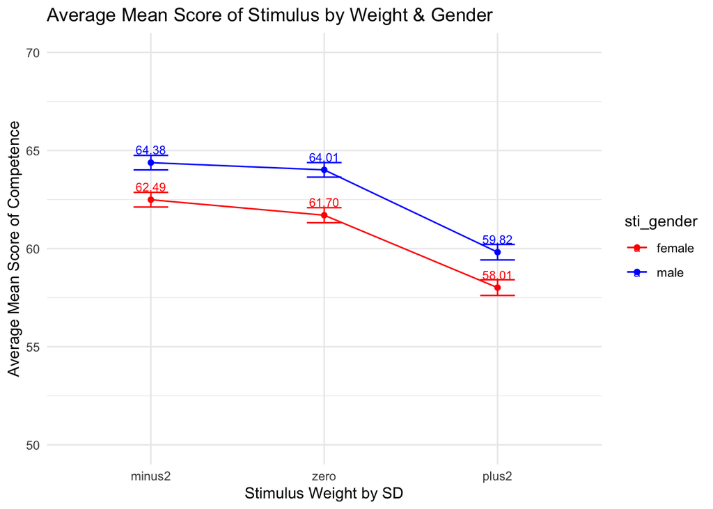

Figure 7.1: Average Mean Score of Stimulus by Weight and Gender

```r
summary_df <- summary_df %>%
  mutate(sti_weight = factor(sti_weight, levels = c("minus2", "zero", "plus2")))
ggplot(summary_df, aes(x = sti_weight,
                       y = mean,
                       color = sti_gender,
                       group = sti_gender)) +
  geom_line() +
  geom_point()+
  geom_errorbar(aes(ymin = mean - se,
                    ymax = mean + se),
                width = 0.2) +
  scale_y_continuous(limits = c(50, 70)) +
  labs(title = "Average Mean Score of Stimulus by Weight & Gender",
       x = "Stimulus Weight by SD",
       y = "Average Mean Score of Competence") +
  scale_color_manual(values = c("male" = "blue", "female" = "red"))  +
  theme_minimal() +
  geom_text(aes(label = sprintf("%.2f", mean)),
            vjust = -1,
            size = 3)
```

The Figure7.2 shows the mean score of competence of each stimuli by stimuli weight, gender and race.

```r
summary_df_race <- anova_data %>%
  group_by(sti_gender,sti_weight,sti_race) %>%
  summarize(
    mean = mean(responses, na.rm = TRUE),
    se = sd(responses, na.rm = TRUE) / sqrt(n()))
```

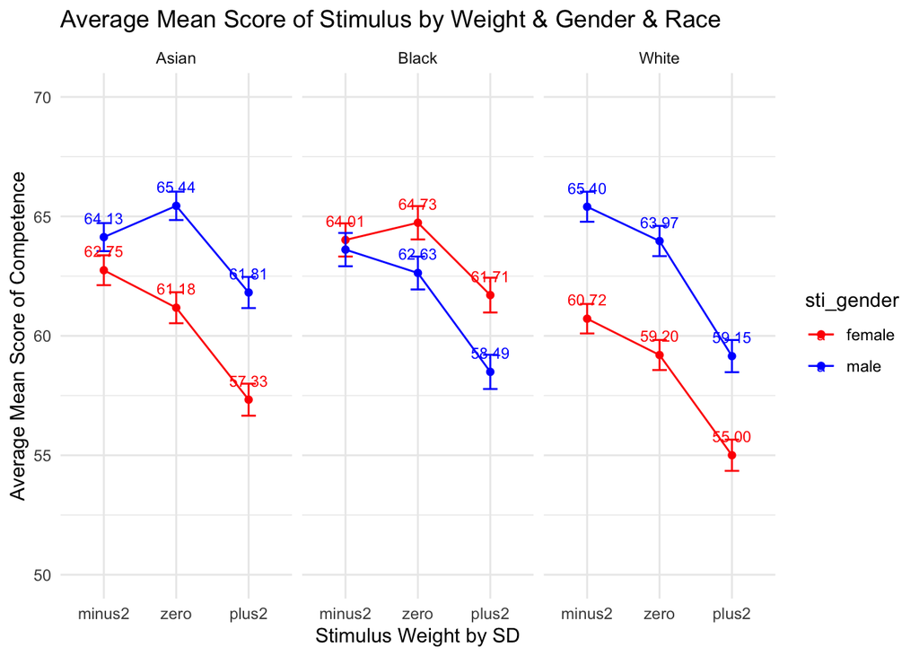

Figure 7.2: Average Mean Score of Stimulus by Weight, Gender and Race

```r
summary_df_race <- summary_df_race %>%
  mutate(sti_weight = factor(sti_weight, levels = c("minus2", "zero", "plus2")))
ggplot(summary_df_race, aes(x = sti_weight,
                              y = mean,
                              color = sti_gender,
                              group = sti_gender)) +
  facet_wrap(~ sti_race, scales = "fixed") +
  geom_line() +
  geom_point() +
  geom_errorbar(aes(ymin = mean - se,
                    ymax = mean + se),
                width = 0.2)+
  scale_y_continuous(limits = c(50, 70)) +
  labs(title = "Average Mean Score of Stimulus by Weight & Gender & Race",
       x = "Stimulus Weight by SD",
       y = "Average Mean Score of Competence") +
  scale_color_manual(values = c("male" = "blue", "female" = "red"))+
  theme_minimal()+
  geom_text(aes(label = sprintf("%.2f", mean)),
            vjust = -1.2,
            hjust = 0.5,
            check_overlap = TRUE,
            size = 3)
```

# 8 Pariticipants

## 8.1 Filter valid participants and their answers

```r
valid_participants <- responses$PROLIFIC_PID
responses_p <- openq_full %>%
  filter(Participant.id %in% valid_participants) %>%
  select(Participant.id, sex, race) %>%
  left_join(responses, by = c("Participant.id" = "PROLIFIC_PID"))
```

Participants participated in an online study for monetary compensation via Prolific. (n = 135, 83 female, 50 male)

The Figure8.1 shows participants’ demographic information by gender.

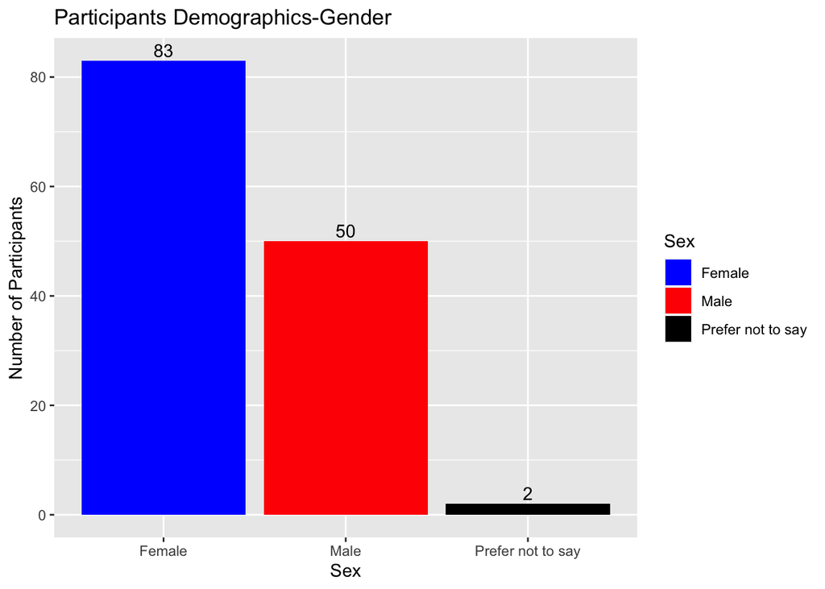

Figure 8.1: Participants Demographics-Gender

```r
# Plot the bar chart
ggplot(responses_p, aes(x = sex)) +
  geom_bar(aes(fill = sex)) +
  geom_text(stat = 'count', aes(label = ..count..,
                                y = ..count..),
            vjust = -0.3) +
  scale_fill_manual(values = c("Female" = "blue",
                               "Male" = "red",
                               "Prefer not to say" = "black")) +
  labs(fill = "Sex") +
  labs(title = "Participants Demographics-Gender",
       x = "Sex",
       y = "Number of Participants")
```

The Figure8.2 shows participants’ demographic information by gender and race.

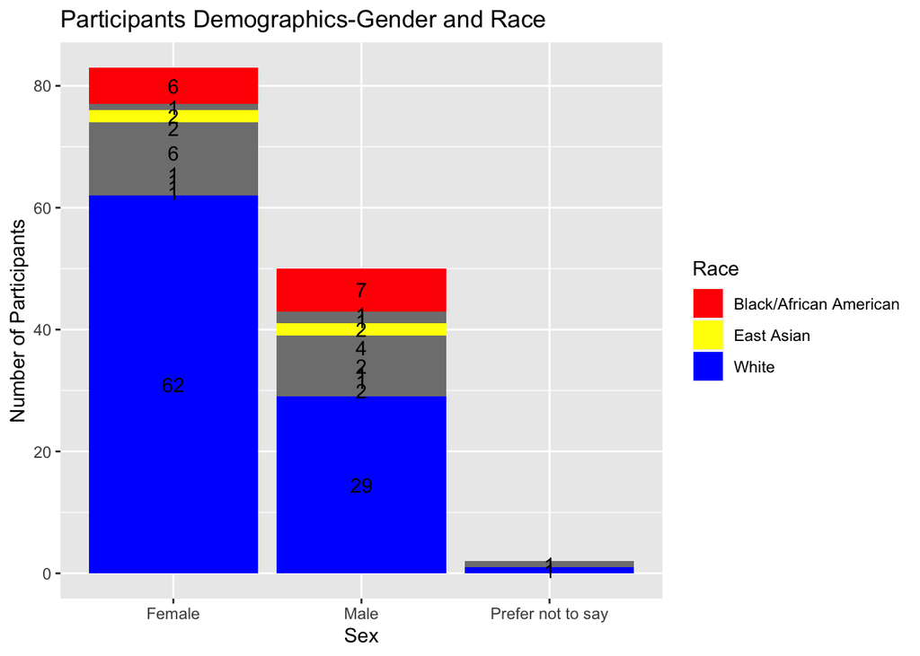

Figure 8.2: Participants Demographics-Gender and Race

```r
ggplot(responses_p, aes(x = sex, fill = race)) +
  geom_bar() +
  geom_text(stat = 'count', aes(label = ..count..,
                                y = ..count..),
            position = position_stack(vjust = 0.5)) +
  scale_fill_manual(values = c("White" = "blue",
                               "East Asian" = "yellow",
                               "Black/African American" = "red")) +
  labs(title = "Participants Demographics-Gender and Race",
       x = "Sex",
       y = "Number of Participants",
       fill = "Race")
```

## 8.2 Run ANOVA on female participants

```r
anova_subset_female <- responses_p %>%
  filter(sex == "Female") %>%
  select(-sex, -race) %>%
  pivot_longer(
    cols = 2:127,
    names_to = "sti_num",
    values_to = "responses"
  ) %>%
  mutate(sti_gender = if_else(sti_num %in% female_stimuli, "female", "male"),
         sti_weight = case_when(
           sti_num %in% minus2 ~ "minus2",
           sti_num %in% zero ~ "zero",
           sti_num %in% plus2 ~ "plus2"),
         sti_race = case_when(
           sti_num %in% asian ~ "Asian",
           sti_num %in% white ~ "White",
           sti_num %in% black ~ "Black"))

anova_female_data <- anova_subset_female %>%
  group_by(Participant.id, sti_gender, sti_weight) %>%
  summarise(mean_response = mean(responses, na.rm = TRUE))
anova_female_data <- data.frame(anova_female_data)
```

```r
female_anova <- anova_test(data=anova_female_data,
                      dv = "mean_response",
                      wid= "Participant.id",
                      within=c("sti_gender", "sti_weight"),
                      effect.size="pes",
                      detailed=TRUE)
print(get_anova_table(female_anova), options(scipen=9999))
```

```
## ANOVA Table (type III tests)
##
##                  Effect  DFn    DFd         SSn       SSd        F        p
## 1           (Intercept) 1.00  82.00 1926554.368 75210.031 2100.484 3.32e-60
## 2            sti_gender 1.00  82.00     190.726  5654.912    2.766 1.00e-01
## 3            sti_weight 1.43 117.44    1745.472  2004.975   71.387 3.26e-17
## 4 sti_gender:sti_weight 1.84 150.48      33.893   882.395    3.150 5.00e-02
##   p<.05   pes
## 1     * 0.962
## 2       0.033
## 3     * 0.465
## 4     * 0.037
```

```r
caption_html_female <- "<span style='font-family: Times; font-size: 16px; font-style: italic;'>Female participants ANOVA</span>"

female_anova_kable <- kable(female_anova$ANOVA, format = "html", caption = caption_html_female) %>%
 add_header_above(c(" " = 1, "Degrees of Freedom" = 2, "Sum of Squares" = 2, "F and p-Values" = 3, "Effect Size" = 1)) %>%
  # Alternating row colors for readability
  row_spec(0:4, background = rep(c("#f7f7f7", "#ffffff"), length.out = 5)) %>%
  # Highlighting significant p-values in red and bold
  row_spec(which(anova_data$`p<.05` == "*"), color = "red", bold = TRUE) %>%
  # Aligning the table to the left, not full width, and setting font size
  kable_styling(position = "left", full_width = F, font_size = 12)

female_anova_kable
```

(#tab:female ANOVA kable )Female participants ANOVA

Degrees of Freedom

Sum of Squares

F and p-Values

Effect Size

Effect

DFn

DFd

SSn

SSd

F

p

p<.05

pes

(Intercept)

1

82

1926554.368

75210.031

2100.484

0.000

0.962

sti_gender

1

82

190.726

5654.912

2.766

0.100

0.033

sti_weight

2

164

1745.472

2004.975

71.387

0.000

0.465

sti_gender:sti_weight

2

164

33.893

882.395

3.150

0.045

0.037

Plot

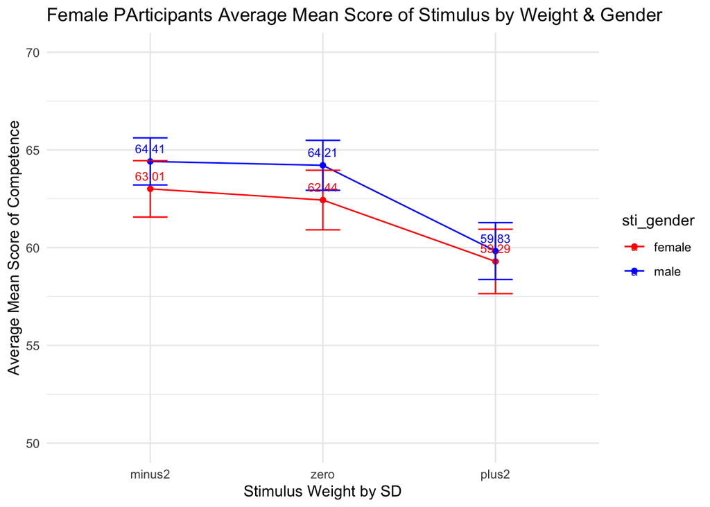

```r
summary_df2 <- anova_female_data %>%
  group_by(sti_gender,sti_weight) %>%
  summarize(
    mean = mean(mean_response, na.rm = TRUE),
    se = sd(mean_response, na.rm = TRUE) / sqrt(n()))

summary_df2 <- summary_df2 %>%
  mutate(sti_weight = factor(sti_weight, levels = c("minus2", "zero", "plus2")))

ggplot(summary_df2, aes(x = sti_weight,
                       y = mean,
                       color = sti_gender,
                       group = sti_gender)) +
  geom_line() +
  geom_point()+
  geom_errorbar(aes(ymin = mean - se,
                    ymax = mean + se),
                width = 0.2) +
  scale_y_continuous(limits = c(50, 70)) +
  labs(title = "Female PArticipants Average Mean Score of Stimulus by Weight & Gender",
       x = "Stimulus Weight by SD",
       y = "Average Mean Score of Competence") +
  scale_color_manual(values = c("male" = "blue", "female" = "red"))  +
  theme_minimal() +
  geom_text(aes(label = sprintf("%.2f", mean)),
            vjust = -1,
            size = 3)
```

## Run ANOVA on male participants

```r
anova_subset_male <- responses_p %>%
  filter(sex == "Male") %>%
  select(-sex, -race) %>%
  pivot_longer(
    cols = 2:127,
    names_to = "sti_num",
    values_to = "responses"
  ) %>%
  mutate(sti_gender = if_else(sti_num %in% female_stimuli, "female", "male"),
         sti_weight = case_when(
           sti_num %in% minus2 ~ "minus2",
           sti_num %in% zero ~ "zero",
           sti_num %in% plus2 ~ "plus2"),
         sti_race = case_when(
           sti_num %in% asian ~ "Asian",
           sti_num %in% white ~ "White",
           sti_num %in% black ~ "Black"))

anova_male_data <- anova_subset_male %>%
  group_by(Participant.id, sti_gender, sti_weight) %>%
  summarise(mean_response = mean(responses, na.rm = TRUE))
anova_male_data <- data.frame(anova_male_data)
```

```r
male_anova <- anova_test(data=anova_male_data,
                      dv = "mean_response",
                      wid= "Participant.id",
                      within=c("sti_gender", "sti_weight"),
                      effect.size="pes",
                      detailed=TRUE)
print(get_anova_table(male_anova), options(scipen=9999))
```

```
## ANOVA Table (type III tests)
##
##                  Effect  DFn   DFd         SSn       SSd       F        p p<.05
## 1           (Intercept) 1.00 49.00 1108007.837 54379.976 998.389 3.03e-34     *
## 2            sti_gender 1.00 49.00     905.631  4127.625  10.751 2.00e-03     *
## 3            sti_weight 1.31 63.95    1500.015  2264.986  32.451 2.57e-08     *
## 4 sti_gender:sti_weight 1.66 81.41      19.761   545.095   1.776 1.81e-01
##     pes
## 1 0.953
## 2 0.180
## 3 0.398
## 4 0.035
```

```r
caption_html_male <- "<span style='font-family: Times; font-size: 16px; font-style: italic;'>Male participants ANOVA</span>"

male_anova_kable <- kable(male_anova$ANOVA, format = "html", caption = caption_html_male) %>%
 add_header_above(c(" " = 1, "Degrees of Freedom" = 2, "Sum of Squares" = 2, "F and p-Values" = 3, "Effect Size" = 1)) %>%
  # Alternating row colors for readability
  row_spec(0:4, background = rep(c("#f7f7f7", "#ffffff"), length.out = 5)) %>%
  # Highlighting significant p-values in red and bold
  row_spec(which(anova_data$`p<.05` == "*"), color = "red", bold = TRUE) %>%
  # Aligning the table to the left, not full width, and setting font size
  kable_styling(position = "left", full_width = F, font_size = 12)

male_anova_kable
```

(#tab:male ANOVA kable )Male participants ANOVA

Degrees of Freedom

Sum of Squares

F and p-Values

Effect Size

Effect

DFn

DFd

SSn

SSd

F

p

p<.05

pes

(Intercept)

1

49

1108007.837

54379.976

998.389

0.000

0.953

sti_gender

1

49

905.631

4127.625

10.751

0.002

0.180

sti_weight

2

98

1500.015

2264.986

32.451

0.000

0.398

sti_gender:sti_weight

2

98

19.761

545.095

1.776

0.175

0.035

Plot

[figure not shown]

```r
summary_df3 <- anova_male_data %>%
  group_by(sti_gender,sti_weight) %>%
  summarize(
    mean = mean(mean_response, na.rm = TRUE),
    se = sd(mean_response, na.rm = TRUE) / sqrt(n()))

summary_df3 <- summary_df3 %>%
  mutate(sti_weight = factor(sti_weight, levels = c("minus2", "zero", "plus2")))

ggplot(summary_df2, aes(x = sti_weight,
                       y = mean,
                       color = sti_gender,
                       group = sti_gender)) +
  geom_line() +
  geom_point()+
  geom_errorbar(aes(ymin = mean - se,
                    ymax = mean + se),
                width = 0.2) +
  scale_y_continuous(limits = c(50, 70)) +
  labs(title = "Male Participants Average Mean Score of Stimulus by Weight & Gender",
       x = "Stimulus Weight by SD",
       y = "Average Mean Score of Competence") +
  scale_color_manual(values = c("male" = "blue", "female" = "red"))  +
  theme_minimal() +
  geom_text(aes(label = sprintf("%.2f", mean)),
            vjust = -1,
            size = 3)
```

# 9 Post-Hoc Analysis Paired t-tests

## 9.1 TukeyHSD

```r
TukeyHSD(aov(responses~sti_weight, data = anova_data))
```

```
##   Tukey multiple comparisons of means
##     95% family-wise confidence level
##
## Fit: aov(formula = responses ~ sti_weight, data = anova_data)
##
## $sti_weight
##                    diff       lwr        upr     p adj
## plus2-minus2 -4.5218695 -5.417372 -3.6263673 0.0000000
## zero-minus2  -0.5790123 -1.474514  0.3164898 0.2835889
## zero-plus2    3.9428571  3.047355  4.8383593 0.0000000
```

## 9.2 Paired t-tests

```r
paired_data <- anova_data %>% select(sti_weight,responses) %>%
  group_by(sti_weight) %>%
  mutate(id = row_number()) %>%
  ungroup() %>%
  pivot_wider(names_from = sti_weight, values_from = responses)

# Perform paired t-tests for each comparison
result_minus2_zero <- t.test(paired_data$minus2, paired_data$zero, paired = TRUE)
result_zero_plus2 <- t.test(paired_data$zero, paired_data$plus2, paired = TRUE)
result_minus2_plus2 <- t.test(paired_data$minus2, paired_data$plus2, paired = TRUE)

# Print results
p_adjusted1 <- p.adjust(result_minus2_zero$p.value, method = "bonferroni")
p_adjusted2 <- p.adjust(result_zero_plus2$p.value, method = "bonferroni")
p_adjusted3 <- p.adjust(result_minus2_plus2$p.value, method = "bonferroni")
```

[output not shown]